# ISCB 2022 Gene set enrichment workshop

January Weiner

2022-10-11

```r
library(tidyverse)
library(colorDF)
library(ggplot2)
library(ggbeeswarm)
library(tmod)
library(colorDF)
library(cowplot)
theme_set(theme_minimal())
```

# A simple data set

## Basic analysis

This is a data set that I used in my poster. It is available from GEO and contains RNA-Seq counts for healthy individuals and COVID-19 patients.

The data set has been already processed and downloaded; however, below you will find the code to replicate this procedure.

```r
## this sometimes fails. The RDS of the object is provided
Sys.setenv(VROOM_CONNECTION_SIZE=8*131072)

## with getGEO, we can only get the phenoData
geo <- getGEO("GSE156063")[[1]]
saveRDS(geo, file="GSE156063.geo")
```

```r
geo <- readRDS("GSE156063.geo")
covar <- as(phenoData(geo), "data.frame")

## remove columns with only one value
boring <- map_lgl(covar, ~ length(unique(.x)) == 1)
covar <- covar[ , !boring ]

## clean up
covar <- covar %>%
  dplyr::rename(gender = "gender:ch1") %>%
  mutate(disease = gsub(" .*", "", .data[["disease state:ch1"]])) %>%
  mutate(label = description) %>%
  mutate(group = disease) %>%
  arrange(description) %>%
  dplyr::select(all_of(c("title", "label", "gender", "disease", "group")))
```

```r
## the counts must be downloaded from GEO separately.
if(!file.exists("GSE156063_swab_gene_counts.csv.gz")) {
  download.file("https://ftp.ncbi.nlm.nih.gov/geo/series/GSE156nnn/GSE156063/suppl/GSE156063_swab_gene_counts.csv.gz",
                "GSE156063_swab_gene_counts.csv.gz")
}

counts <- read_csv("GSE156063_swab_gene_counts.csv.gz")
.tmp <- counts[[1]]
counts <- as.matrix(counts[,-1])
rownames(counts) <- .tmp
#counts <- counts[ , covar$description ]
counts <- counts[ , covar$label ]
lcpm   <- edgeR::cpm(counts, log=TRUE)
#stopifnot(all(colnames(counts) == covar$description))
stopifnot(all(colnames(counts) == covar$label))

annot <- data.frame(ENSEMBL = rownames(counts))

.tmp <- mapIds(org.Hs.eg.db, annot$ENSEMBL, column=c("ENTREZID"), keytype="ENSEMBL")
annot$ENTREZID <- .tmp[ match(annot$ENSEMBL, names(.tmp)) ]

.tmp <- mapIds(org.Hs.eg.db, annot$ENSEMBL, column=c("SYMBOL"), keytype="ENSEMBL")
annot$SYMBOL <- .tmp[ match(annot$ENSEMBL, names(.tmp)) ]

.tmp <- mapIds(org.Hs.eg.db, annot$ENSEMBL, column=c("GENENAME"), keytype="ENSEMBL")
annot$GENENAME <- .tmp[ match(annot$ENSEMBL, names(.tmp)) ]
```

```r
sel <- covar$group %in% c("no", "SC2")
counts <- counts[ , sel ]
covar  <- covar[ sel, ]
covar$group <- as.character(covar$group)

covar$group.disease <- paste0(covar$group, '_', covar$disease)
rownames(covar) <- covar$label
saveRDS(covar, file="covar.rds")
saveRDS(counts, file="counts.rds")
```

```r
## DESeq2 calculations
## manual cache, since the operation takes a long time
sel <- !is.na(covar$group)

ds2 <- DESeqDataSetFromMatrix(counts[,sel], colData=covar[sel, ], design=~ disease)

ds2_file <- "ds2_cached.rds"
if(!file.exists(ds2_file)) {
  message("Running DESeq2")
  ds2 <- DESeq(ds2)
  saveRDS(ds2, file=ds2_file)
} else {
  message("Reading ds2 from manual cache")
  ds2 <- readRDS(ds2_file)
}
```

First, take a look at the structure of the data:

```r
covar  <- readRDS("data/covar.rds") # covariates
summary_colorDF(covar)
```

[output not shown]

The results table is stored under “data/disease_SC2_vs_no.tsv”. In `data/annotation.tsv`, there is the annotation of the genes in this data set.

```r
dsres <- read_table("data/disease_SC2_vs_no.tsv")
annot <- read_table("data/annotation.tsv")
dsres <- merge(annot, dsres, by="ENSEMBL")
```

Basic CERNO analysis:

```r
gl <- dsres$SYMBOL[ order(dsres$pvalue) ]
tres <- tmodCERNOtest(gl)
print(tres)
```

```
## # tmod report (class tmodReport) 8 x 107:
## # (Showing rows 1 - 5 out of 107)
##         │ID      │Title                  │cerno│N1   │AUC  │cES  │P.Value
##  DC.M3.4│ DC.M3.4│Interferon             │  425│   48│ 0.89│  4.4│<2e-16
##  DC.M1.2│ DC.M1.2│Interferon             │  296│   24│ 0.99│  6.2│<2e-16
## DC.M5.12│DC.M5.12│Interferon             │  356│   56│ 0.82│  3.2│<2e-16
##  DC.M3.2│ DC.M3.2│Inflammation           │  528│  112│ 0.82│  2.4│<2e-16
##   LI.M75│  LI.M75│antiviral IFN signature│  198│   21│ 0.91│  4.7│<2e-16
##         │adj.P.Val
##  DC.M3.4│  3.9e-40
##  DC.M1.2│  5.6e-35
## DC.M5.12│  7.7e-25
##  DC.M3.2│  1.8e-24
##   LI.M75│  5.6e-20
```

Which we can quickly visualize:

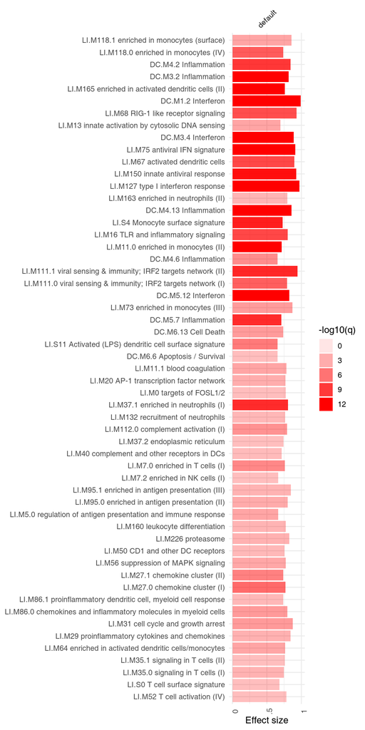

```r
ggPanelplot(tres)
```

We can also add information about whether the genes go up or down. Note that we need to put `tres` inside a list, so `ggPanelplot` can match tmod results with the `sgenes` object.

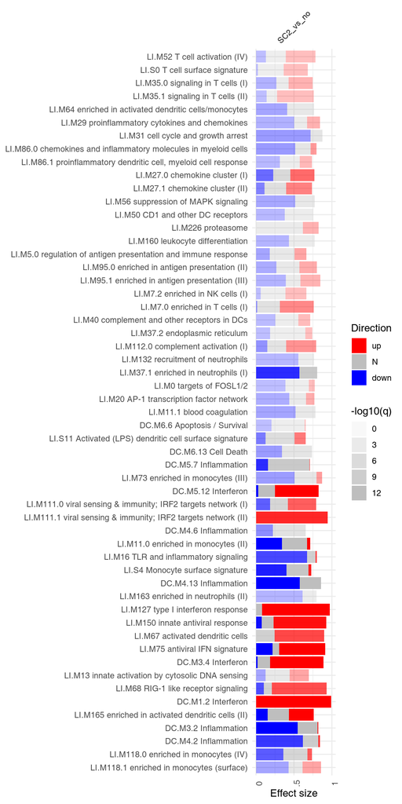

```r
sgenes <- tmodDecideTests(dsres$SYMBOL, lfc = dsres$log2FoldChange,
                          pval=dsres$pvalue)
names(sgenes) <- "SC2_vs_no"
tres <- list("SC2_vs_no"=tres)
ggPanelplot(tres, sgenes=sgenes)
```

## Using another gene sets

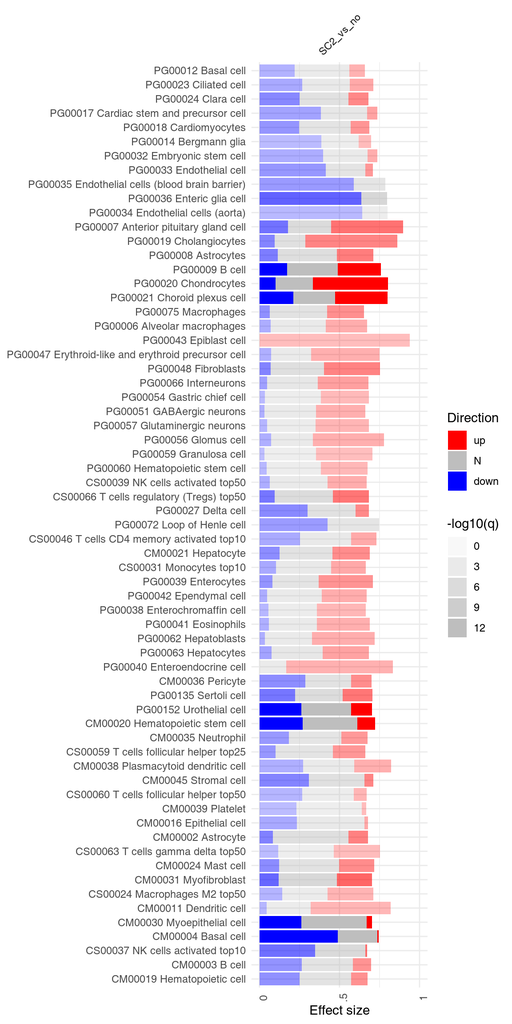

```r
data(cell_signatures)
tres2 <- tmodCERNOtest(gl, mset=cell_signatures)

tres2 <- list("SC2_vs_no"=tres2)
sgenes2 <- tmodDecideTests(dsres$SYMBOL, lfc = dsres$log2FoldChange,
                          pval=dsres$pvalue, mset=cell_signatures)
names(sgenes2) <- "SC2_vs_no"
ggPanelplot(tres2, sgenes=sgenes2, mset=cell_signatures)
```

The mset parameter is used in most of the functions to use another gene sets.

## Inspecting individual enrichments

Let us consider the gene set “LI.M68” – RIG-1 like receptor signalling. First, show the genes in this gene set:

```r
data(tmod) # make the built-in gene sets visible
getModuleMembers("LI.M68", mset=tmod)
```

```
## $LI.M68
##  [1] "DDX58"  "IRF7"   "DHX58"  "TRIM25" "NFKBIA" "IFIH1"  "TNF"    "ISG15"
##  [9] "CXCL10" "IL8"
```

Evidence plot – a ROC curve:

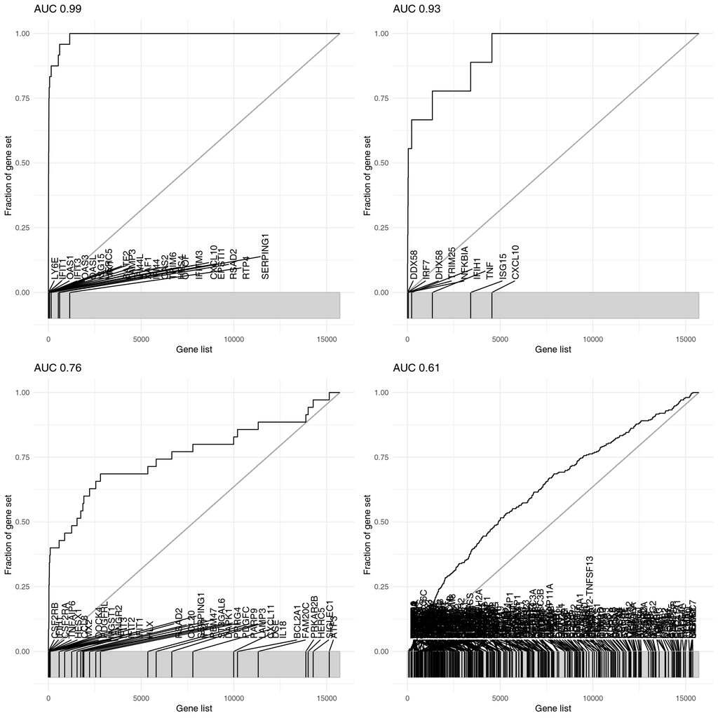

```r
g1 <- ggEvidencePlot(gl, m = "DC.M1.2") + ggtitle("AUC 0.99")
g2 <- ggEvidencePlot(gl, m = "LI.M68") + ggtitle("AUC 0.93")
g3 <- ggEvidencePlot(gl, m = "LI.M165") + ggtitle("AUC 0.76")
g4 <- ggEvidencePlot(gl, m = "LI.M4.0") + ggtitle("AUC 0.61")
plot_grid(g1, g2, g3, g4, nrow=2)
```

# Eigengenes

The basic idea is as follos: run PCA only on a selected group of genes, use PC1 instead of average gene expression of that gene set (mind the signs!). Below, `counts.rds` contains the raw RNA-seq counts, which I first convert to log<sub>2</sub> counts per million.

```r
counts <- readRDS("data/counts.rds")

lcpm <- edgeR::cpm(counts, log=TRUE)
mm <- getModuleMembers("LI.M68", mset=tmod)[[1]]
sel <- annot$SYMBOL %in% mm
covar$eig <- prcomp(t(lcpm[ sel, ]), scale.=TRUE)$x[,1]
```

We can use eigengenes to nicely plot the results:

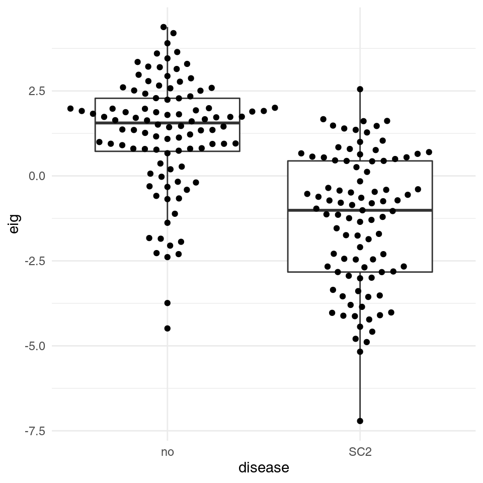

```r
ggplot(covar, aes(x=disease, y=eig)) + geom_boxplot(outlier.shape = NA) +
  geom_beeswarm(cex=3)
```

(However, mind the sign!)

In tmod, eigengenes can be computed directly. Tmod makes sure that the eigengene correlates positively with the majority of the genes in the gene set and reverses the sign when necessary:

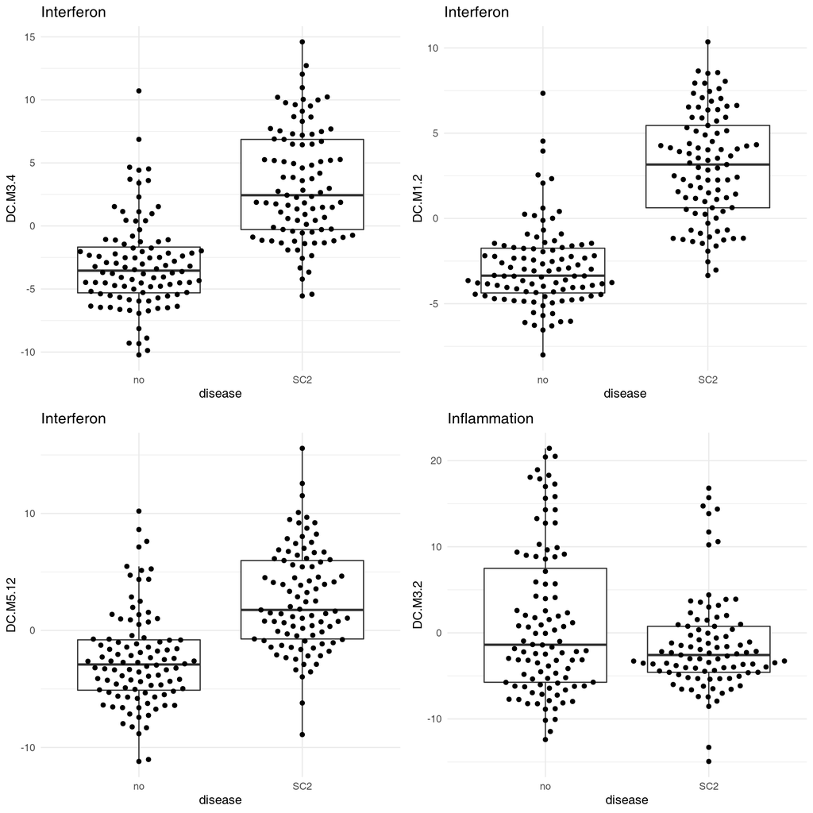

```r
selm <- tres[[1]]$ID[1:4]
eig <- eigengene(lcpm, annot$SYMBOL)
eig <- as.data.frame(t(eig)) %>%
  select(all_of(selm)) %>%
  rownames_to_column("label") %>%
  inner_join(covar, by="label")
plots <- map(selm, ~ ggplot(eig, aes_string(x="disease", y=.x)) +
             geom_boxplot(outlier.shape=NA) +
             geom_beeswarm(cex=3) +
             ggtitle(tres[[1]]$Title[ match(.x, tres[[1]]$ID) ]))
plot_grid(plotlist=plots)
```

# Combining gene set enrichments with PCA

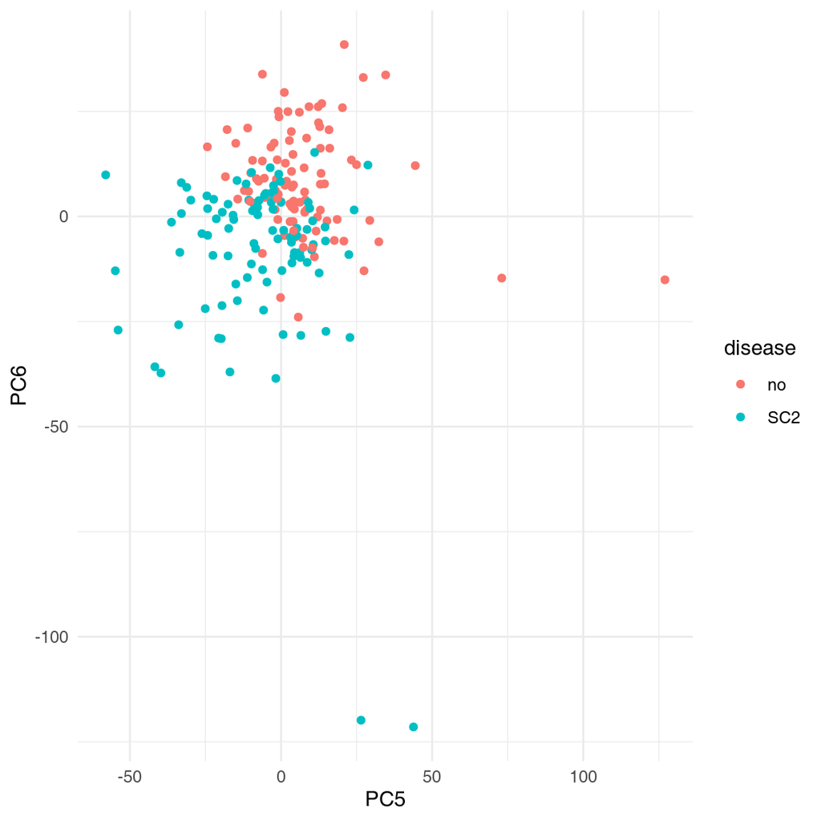

```r
pca <- prcomp(t(lcpm), scale.=TRUE)
pca_df <- pca$x %>% as.data.frame %>%
  rownames_to_column("label") %>% merge(covar)
ggplot(pca_df, aes(x=PC5, y=PC6, color=disease)) +
  geom_point()
```

# Using gene sets from msigdbr

```r
library(msigdbr)
msig_df <- msigdbr("Homo sapiens")
```

# The vaccination example

This example data set has been published by Weiner et al. (2019). RNA has been collected daily from individuals vaccinated with one of seven vaccines over the course of several days. The data set has been collected using microarrays. The pre-calculated results include two influenza vaccines, one containing an adjuvant and the other not. For details how to get this table, see the online tmod manual [here](https://january3.github.io/tmod/articles/user_manual/tmod_user_manual.html), section “Transcriptional responses to vaccination”.

```r
tt <- readRDS("data/vaccination_toptable.rds")
```

The subset contains results for 5 time points for two vaccines (10 contrasts in total). The two vaccines are denoted with “A” (no adjuvant) and “F” (adjuvant). We will run gene set enrichment on each of these time points using `tmodCERNOtest`.

```r
contrasts_v <- paste0(rep(c("F", "A"), each=5), "_", 1:5)
sort_cols <- paste0("qval.", contrasts_v)
res <- map(sort_cols, ~ {
  tmodCERNOtest(tt$GENE_SYMBOL[ order(tt[[.x]]) ])
})
names(res) <- contrasts_v
```

The figure below shows the results.

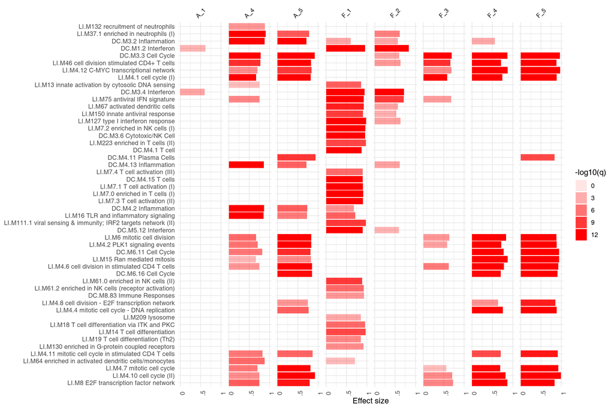

```r
ggPanelplot(res, filter_row_q = 1e-3, filter_row_auc = .85, q_thr=0.01)
```

Do these gene sets contain genes that go up or down? For this, we need to determine how many genes in each gene set are significantly going up or down.

```r
pval <- tt %>% select(starts_with("qval"))
lfc  <- tt %>% select(starts_with("logFC"))
sgenes <- tmodDecideTests(tt$GENE_SYMBOL, lfc=lfc, pval=pval)
names(sgenes) <- contrasts_v
```

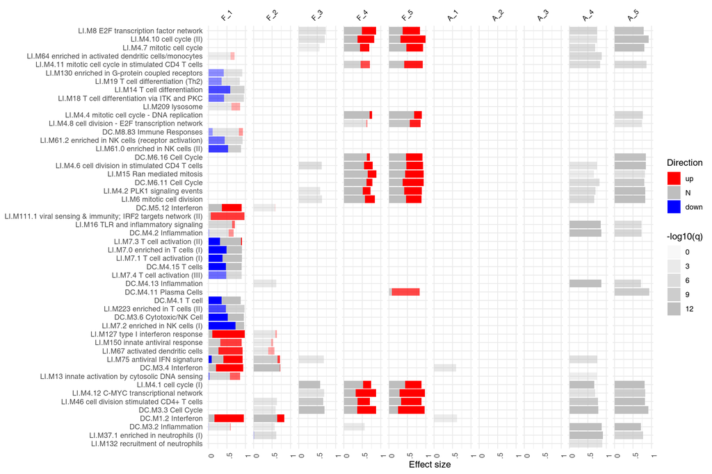

```r
ggPanelplot(res, sgenes=sgenes, filter_row_q = 1e-3, filter_row_auc = .85, q_thr=0.01)
```

Weiner, January, David JM Lewis, Jeroen Maertzdorf, Hans-Joachim Mollenkopf, Caroline Bodinham, Kat Pizzoferro, Catherine Linley, et al. 2019. “Characterization of Potential Biomarkers of Reactogenicity of Licensed Antiviral Vaccines: Randomized Controlled Clinical Trials Conducted by the BIOVACSAFE Consortium.” *Scientific Reports* 9 (1): 1–14.